# Project 3 Exploratory Data Analysis

Giulio Ministeri

11/04/2015

For this Nanodegree project, I decided to find a dataset on my own.  
Thanks to Udacity and to this Nanodegree project, few months ago I discovered the website Kaggle.com; a very interesting website that hosts companies or academic instutions which want to challenge data scientists all over the world and get some help in solving their current issues.  
So far I’ve been surfing pages and projects and look what is going on there, never submitted a solution or attempted to get involved in any of the competions.  
I chose to pick a dataset from one of the Kaggle competitions and use it to complete this Nanodegree project, with the hope of raising the attention of the reviewer, probably bored after reviewing hundreds of projects about wine ;-) .  
The dataset is available here: http://www.kaggle.com/c/bike-sharing-demand and it is about bike sharing. Basically It is asked to find a good predictor to forecast the number of bike rentals using features like date, time of the day and weather-related features like temperature, humidity, ecc… The dataset have been collected through the Washington D.C. bike sharing program.  
Here is the features list description as presented by the authors of the competition:  
Data Fields:

- datetime, hourly date + timestamp
- season, 1 = spring, 2 = summer, 3 = fall, 4 = winter
- holiday, whether the day is considered a holiday
- workingday, whether the day is neither a weekend nor holiday
- weather, 1: Clear, Few clouds, Partly cloudy, Partly cloudy 2: Mist + Cloudy, Mist + Broken clouds, Mist + Few clouds, Mist 3: Light Snow, Light Rain + Thunderstorm + Scattered clouds, Light Rain + Scattered clouds 4: Heavy Rain + Ice Pallets + Thunderstorm + Mist, Snow + Fog
- temp, temperature in Celsius
- atemp, “feels like” temperature in Celsius
- humidity, relative humidity
- windspeed - wind speed
- casual, number of non-registered user rentals initiated
- registered, number of registered user rentals initiated
- count, number of total rentals

I decided to change the name “count” to “total_rent” to avoid misunderstanding in histogram plots

```
## [1] 10886    12
```

```
##  [1] "datetime"   "season"     "holiday"    "workingday" "weather"
##  [6] "temp"       "atemp"      "humidity"   "windspeed"  "casual"
## [11] "registered" "total_rent"
```

```
##                 datetime         season         holiday
##  2011-01-01 00:00:00:    1   Min.   :1.000   Min.   :0.00000
##  2011-01-01 01:00:00:    1   1st Qu.:2.000   1st Qu.:0.00000
##  2011-01-01 02:00:00:    1   Median :3.000   Median :0.00000
##  2011-01-01 03:00:00:    1   Mean   :2.507   Mean   :0.02857
##  2011-01-01 04:00:00:    1   3rd Qu.:4.000   3rd Qu.:0.00000
##  2011-01-01 05:00:00:    1   Max.   :4.000   Max.   :1.00000
##  (Other)            :10880
##    workingday        weather           temp           atemp
##  Min.   :0.0000   Min.   :1.000   Min.   : 0.82   Min.   : 0.76
##  1st Qu.:0.0000   1st Qu.:1.000   1st Qu.:13.94   1st Qu.:16.66
##  Median :1.0000   Median :1.000   Median :20.50   Median :24.24
##  Mean   :0.6809   Mean   :1.418   Mean   :20.23   Mean   :23.66
##  3rd Qu.:1.0000   3rd Qu.:2.000   3rd Qu.:26.24   3rd Qu.:31.06
##  Max.   :1.0000   Max.   :4.000   Max.   :41.00   Max.   :45.45
##
##     humidity        windspeed          casual         registered
##  Min.   :  0.00   Min.   : 0.000   Min.   :  0.00   Min.   :  0.0
##  1st Qu.: 47.00   1st Qu.: 7.002   1st Qu.:  4.00   1st Qu.: 36.0
##  Median : 62.00   Median :12.998   Median : 17.00   Median :118.0
##  Mean   : 61.89   Mean   :12.799   Mean   : 36.02   Mean   :155.6
##  3rd Qu.: 77.00   3rd Qu.:16.998   3rd Qu.: 49.00   3rd Qu.:222.0
##  Max.   :100.00   Max.   :56.997   Max.   :367.00   Max.   :886.0
##
##    total_rent
##  Min.   :  1.0
##  1st Qu.: 42.0
##  Median :145.0
##  Mean   :191.6
##  3rd Qu.:284.0
##  Max.   :977.0
##
```

First, I noticed that “datetime” feature includes too many information, I splitted into four new features: hour, day, month and year (minutes and seconds are always equal to 0).

```r
tmp <- data.frame( DateTime=dts$datetime, time=format(as.POSIXct(dts$datetime, format="%Y-%m-%d %H:%M:%S"), format="%H"), day=format(as.POSIXct(dts$datetime, format="%Y-%m-%d %H:%M:%S"), format="%d"), month=format(as.POSIXct(dts$datetime, format="%Y-%m-%d %H:%M:%S"), format="%m"), year=format(as.POSIXct(dts$datetime, format="%Y-%m-%d %H:%M:%S"), format="%Y"))
dts$hour <- as.numeric(tmp$time)
dts$day <- as.numeric(tmp$day)
dts$month <- as.numeric(tmp$month)
dts$year <- tmp$year
dts$datetime <- NULL
```

After the extraction:

```
##      season         holiday          workingday        weather
##  Min.   :1.000   Min.   :0.00000   Min.   :0.0000   Min.   :1.000
##  1st Qu.:2.000   1st Qu.:0.00000   1st Qu.:0.0000   1st Qu.:1.000
##  Median :3.000   Median :0.00000   Median :1.0000   Median :1.000
##  Mean   :2.507   Mean   :0.02857   Mean   :0.6809   Mean   :1.418
##  3rd Qu.:4.000   3rd Qu.:0.00000   3rd Qu.:1.0000   3rd Qu.:2.000
##  Max.   :4.000   Max.   :1.00000   Max.   :1.0000   Max.   :4.000
##       temp           atemp          humidity        windspeed
##  Min.   : 0.82   Min.   : 0.76   Min.   :  0.00   Min.   : 0.000
##  1st Qu.:13.94   1st Qu.:16.66   1st Qu.: 47.00   1st Qu.: 7.002
##  Median :20.50   Median :24.24   Median : 62.00   Median :12.998
##  Mean   :20.23   Mean   :23.66   Mean   : 61.89   Mean   :12.799
##  3rd Qu.:26.24   3rd Qu.:31.06   3rd Qu.: 77.00   3rd Qu.:16.998
##  Max.   :41.00   Max.   :45.45   Max.   :100.00   Max.   :56.997
##      casual         registered      total_rent         hour
##  Min.   :  0.00   Min.   :  0.0   Min.   :  1.0   Min.   : 1.00
##  1st Qu.:  4.00   1st Qu.: 36.0   1st Qu.: 42.0   1st Qu.: 7.00
##  Median : 17.00   Median :118.0   Median :145.0   Median :13.00
##  Mean   : 36.02   Mean   :155.6   Mean   :191.6   Mean   :12.54
##  3rd Qu.: 49.00   3rd Qu.:222.0   3rd Qu.:284.0   3rd Qu.:19.00
##  Max.   :367.00   Max.   :886.0   Max.   :977.0   Max.   :24.00
##       day             month          year
##  Min.   : 1.000   Min.   : 1.000   2011:5422
##  1st Qu.: 5.000   1st Qu.: 4.000   2012:5464
##  Median :10.000   Median : 7.000
##  Mean   : 9.993   Mean   : 6.521
##  3rd Qu.:15.000   3rd Qu.:10.000
##  Max.   :19.000   Max.   :12.000
```

```
##   season holiday workingday weather temp  atemp humidity windspeed casual
## 1      1       0          0       1 9.84 14.395       81    0.0000      3
## 2      1       0          0       1 9.02 13.635       80    0.0000      8
## 3      1       0          0       1 9.02 13.635       80    0.0000      5
## 4      1       0          0       1 9.84 14.395       75    0.0000      3
## 5      1       0          0       1 9.84 14.395       75    0.0000      0
## 6      1       0          0       2 9.84 12.880       75    6.0032      0
##   registered total_rent hour day month year
## 1         13         16    1   1     1 2011
## 2         32         40    2   1     1 2011
## 3         27         32    3   1     1 2011
## 4         10         13    4   1     1 2011
## 5          1          1    5   1     1 2011
## 6          1          1    6   1     1 2011
```

Looking at the column “season” I noticed two things:

- the season labels are wrong: january the first which should be winter, is marked as “season=1” which they say it is spring;
- the dataset seems to be equally distributed and to cover the whole year.

Of course the holidays are very rare and working days are more frequent. Temperature is very warm, and humidity is very high and, in fact the felt temperature is bigger of 3 to 5 degrees. Wind is also a constant presence, but never annoying: looking at the quartiles, (and assuming wind is measured in knots) the wind speed is below the 17 knots, I am not so expert about wind speeds but I think that at these speeds wind can be considered almost a breeze.

## Univariate plots section

As a first step I want to take a look at data about weather and climate.

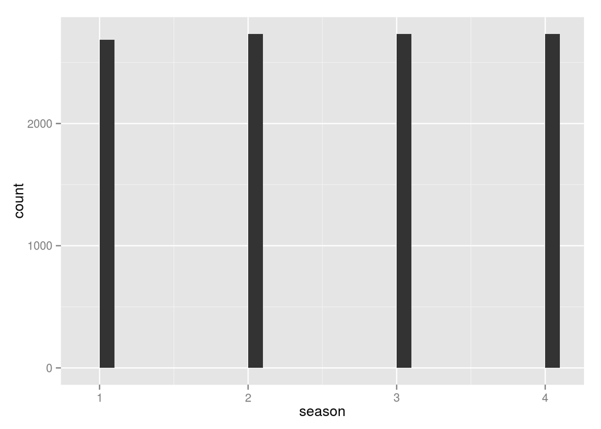

As already noticed, data are equally distributed among seasons.

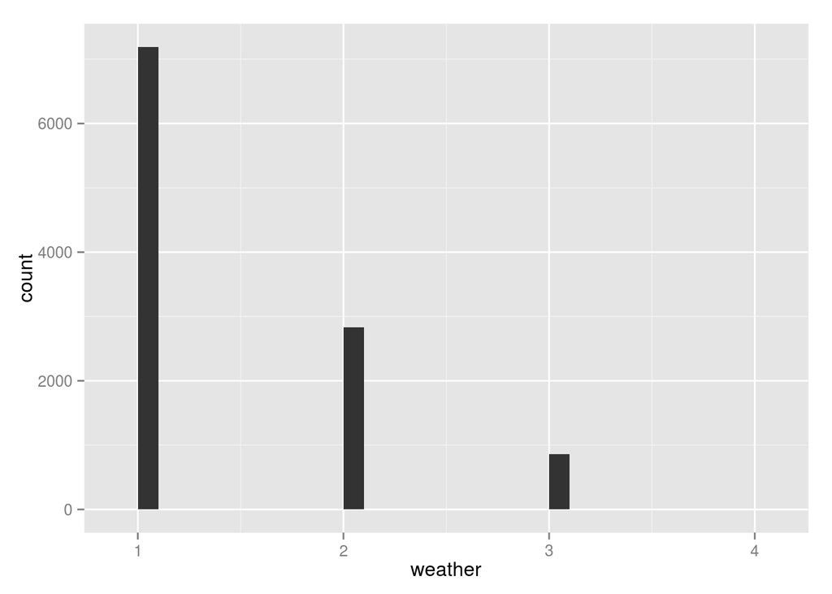

```r
ggplot(dts, aes(x=weather)) + geom_histogram()
```

It is a very sunny place, very few days with rain or bad weather.

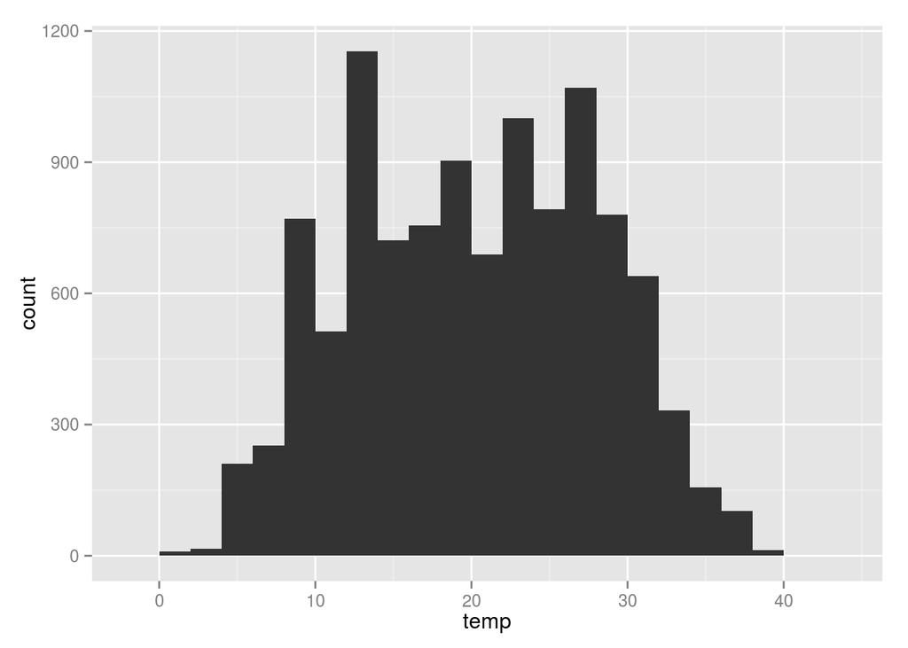

```r
ggplot(dts, aes(x=temp)) + geom_histogram(binwidth=2)
```

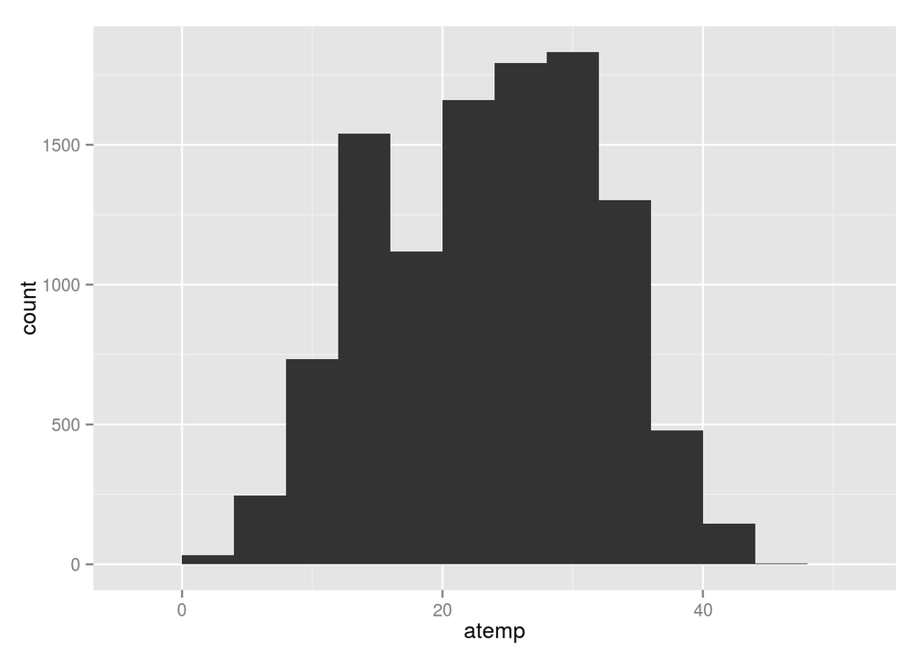

```r
ggplot(dts, aes(x=atemp)) + geom_histogram(binwidth=4)
```

Also temperature seems not to be a problem for bikers, very few days with prohibitive temperatures. The temperature distribution has an indefinable shape, but I think I can say it is unimodal, close to the gaussian shape.

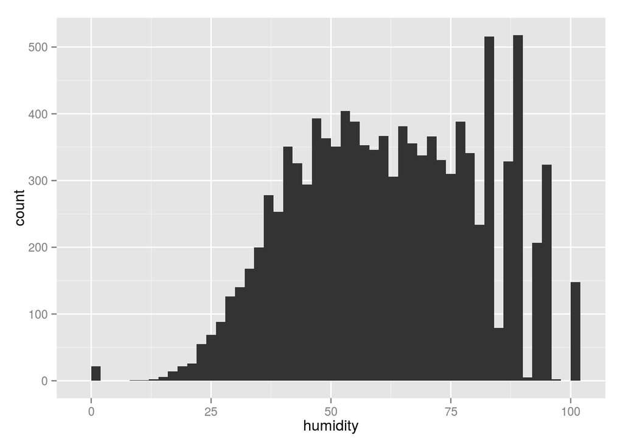

```r
ggplot(dts, aes(x=humidity)) + geom_histogram(binwidth=2)
```

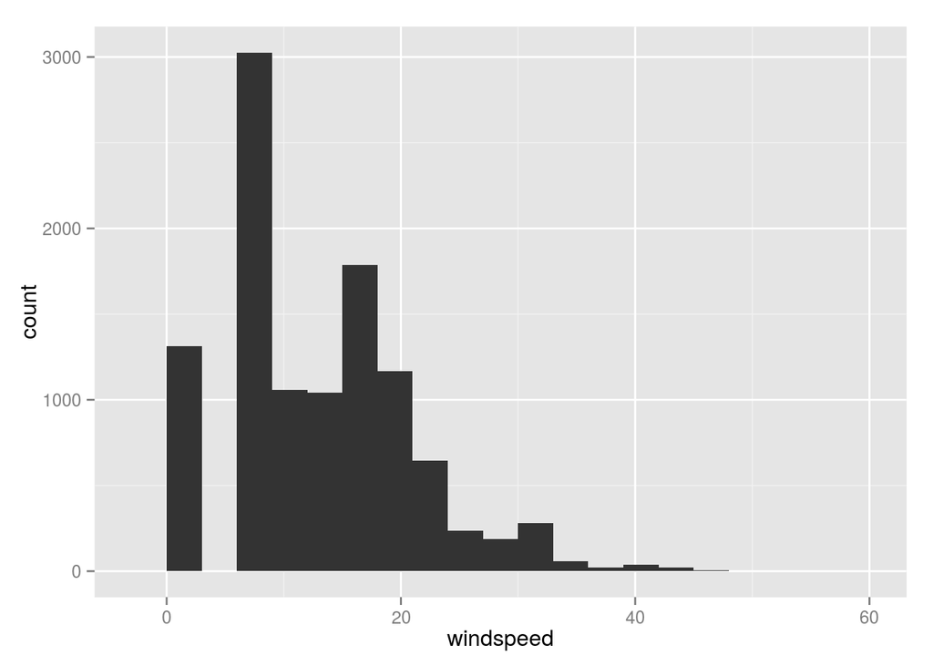

```r
ggplot(dts, aes(x=windspeed)) + geom_histogram(binwidth=3)
```

Very sunny and warm place, lot of humidity and quite often wind with low speed. It seems we are in a city near the coast. I am not from U.S. and I am not a climate expert but I thing Washington D.C. can be considered a coast city, or at least a city where the influence of the sea on local climate is strong.

For the sake of completeness, before diving into the biker rental numbers, I graph the holidays and working days histogram.

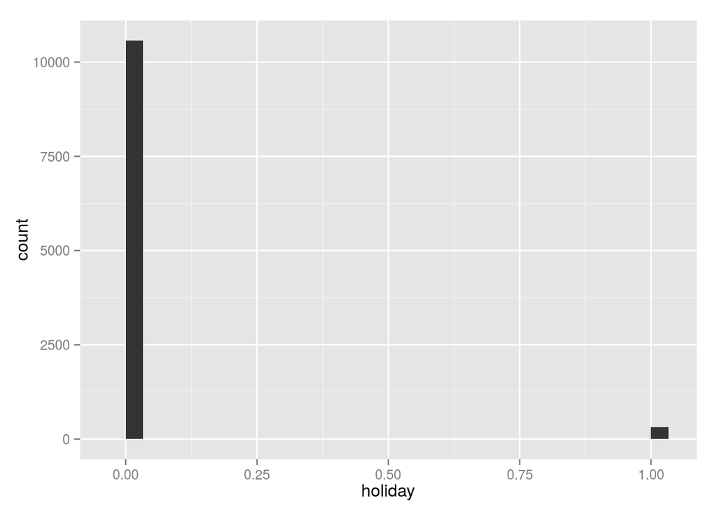

```r
ggplot(dts, aes(x=holiday)) + geom_histogram()
```

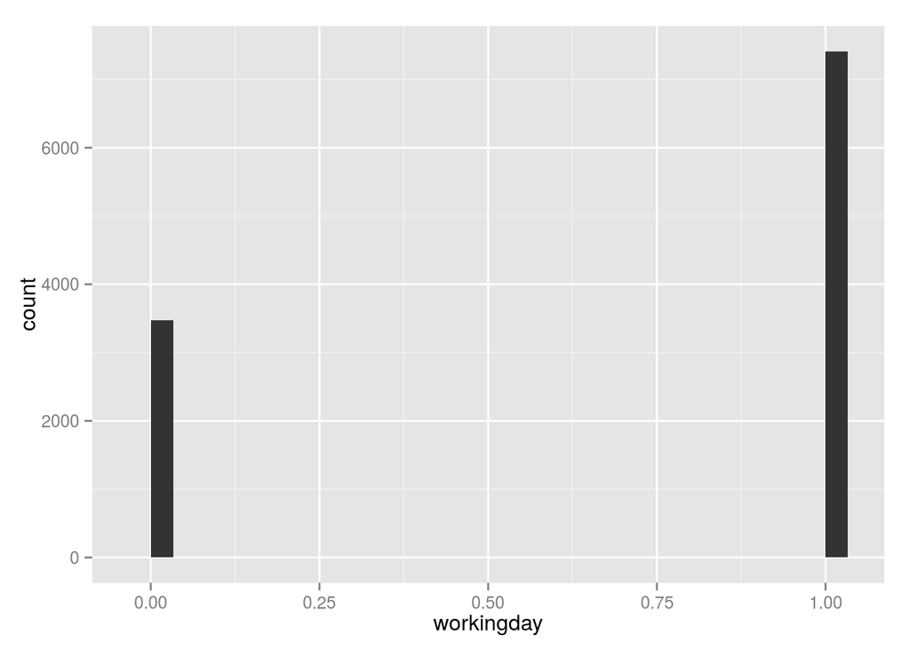

```r
ggplot(dts, aes(x=workingday)) + geom_histogram()
```

As expected most of the days are working days and very few are holidays. Let me check if these two variables are mutually exclusive, i.e. if it is a working day it is not an holiday and viceversa.

```r
dim(subset(dts, workingday==1 & holiday==1 & hour==12))
```

```
## [1]  0 15
```

```r
dim(subset(dts, workingday==0 & holiday==0 & hour==12))
```

```
## [1] 132  15
```

```r
head(subset(dts, workingday==0 & holiday==0 & hour==12), n= 3)
```

```
##     season holiday workingday weather  temp  atemp humidity windspeed
## 12       1       0          0       1 14.76 16.665       81   19.0012
## 35       1       0          0       2 14.76 16.665       71   16.9979
## 173      1       0          0       2  8.20  9.090       69   26.0027
##     casual registered total_rent hour day month year
## 12      26         30         56   12   1     1 2011
## 35      16         54         70   12   2     1 2011
## 173      2         60         62   12   8     1 2011
```

Holidays are not working days (as expected), but not all the not workingdays are holidays, probably weekends are considered neither working days nor holidays. A quick check in a 2011 calendar reveals my hypothesis is right.

The added features about time:

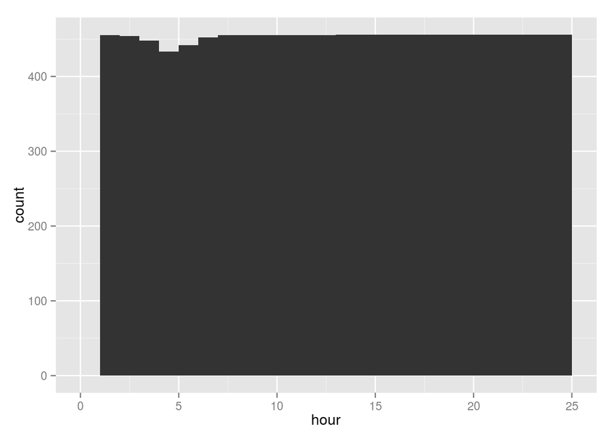

```r
ggplot(dts, aes(x=hour)) + geom_histogram(binwidth=1)
```

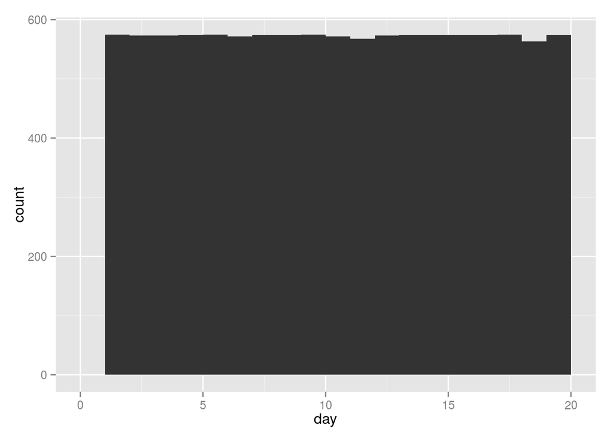

```r
ggplot(dts, aes(x=day)) + geom_histogram(binwidth=1)
```

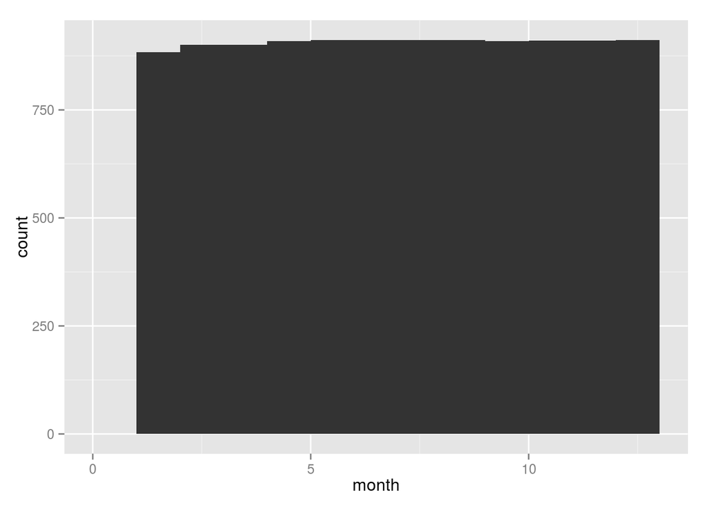

```r
ggplot(dts, aes(x=month)) + geom_histogram(binwidth=1)
```

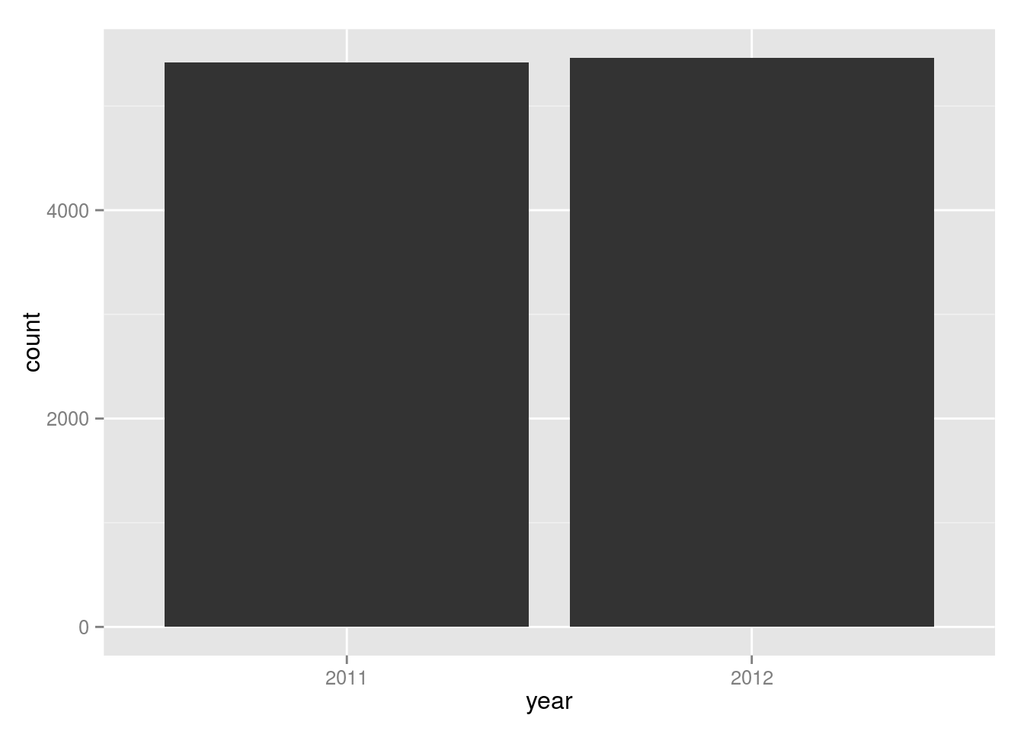

```r
ggplot(dts, aes(x=year)) + geom_histogram(binwidth=1)
```

Now the bike rental data

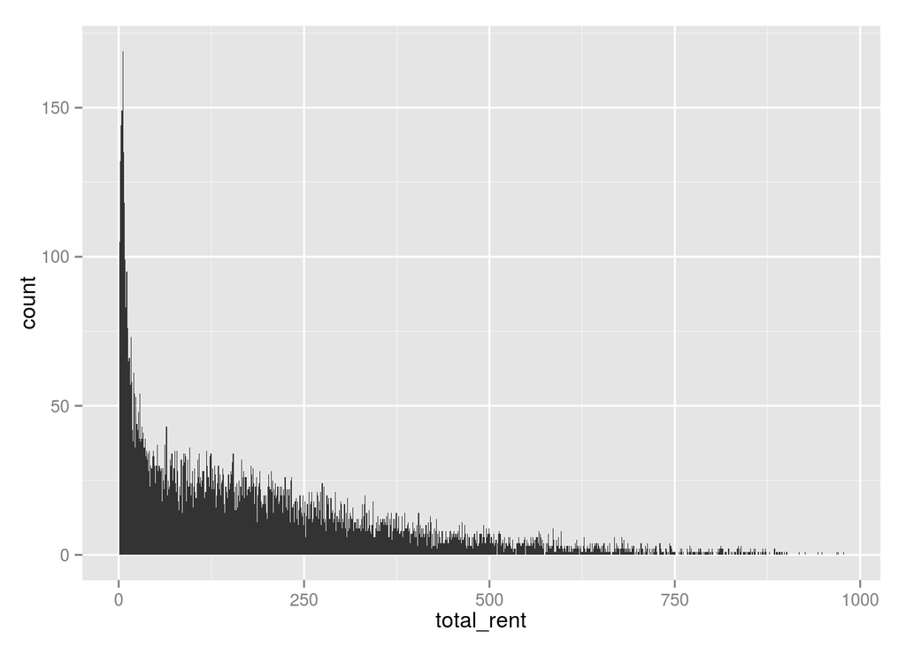

```r
ggplot(dts, aes(x=total_rent)) + geom_histogram(binwidth=1)
```

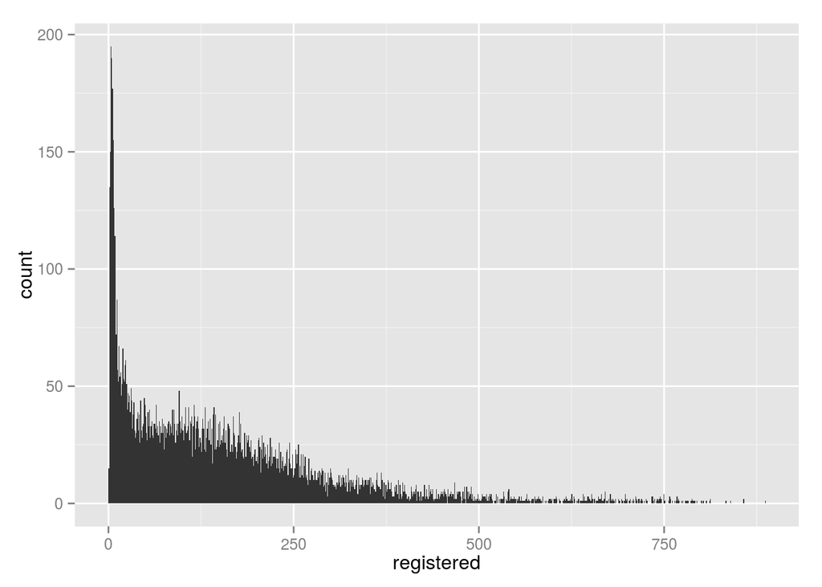

```r
ggplot(dts, aes(x=registered)) + geom_histogram(binwidth=1)
```

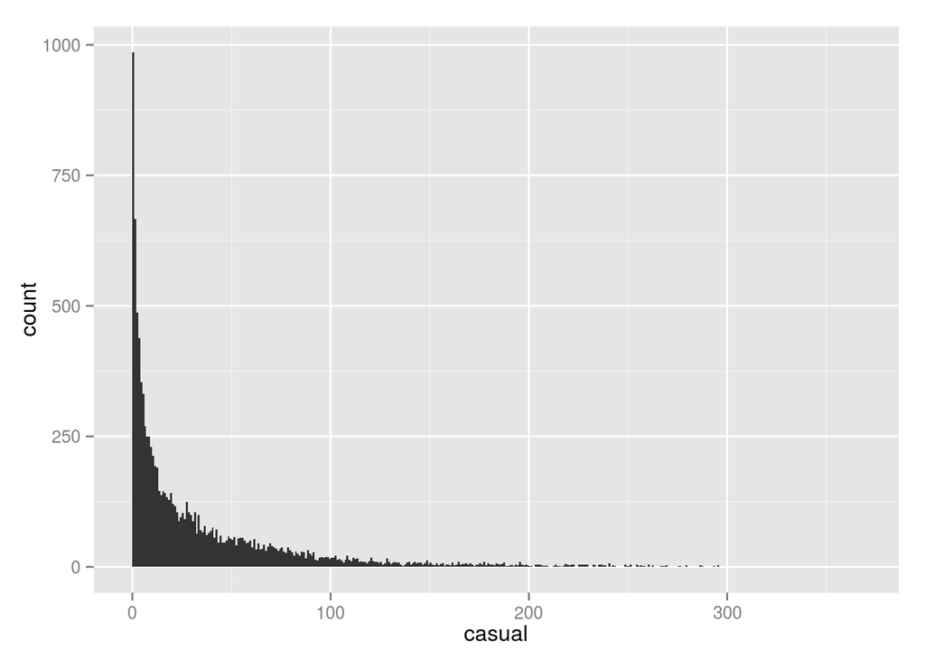

```r
ggplot(dts, aes(x=casual)) + geom_histogram(binwidth=1)
```

which I think they would be clearer in logarithmic scale

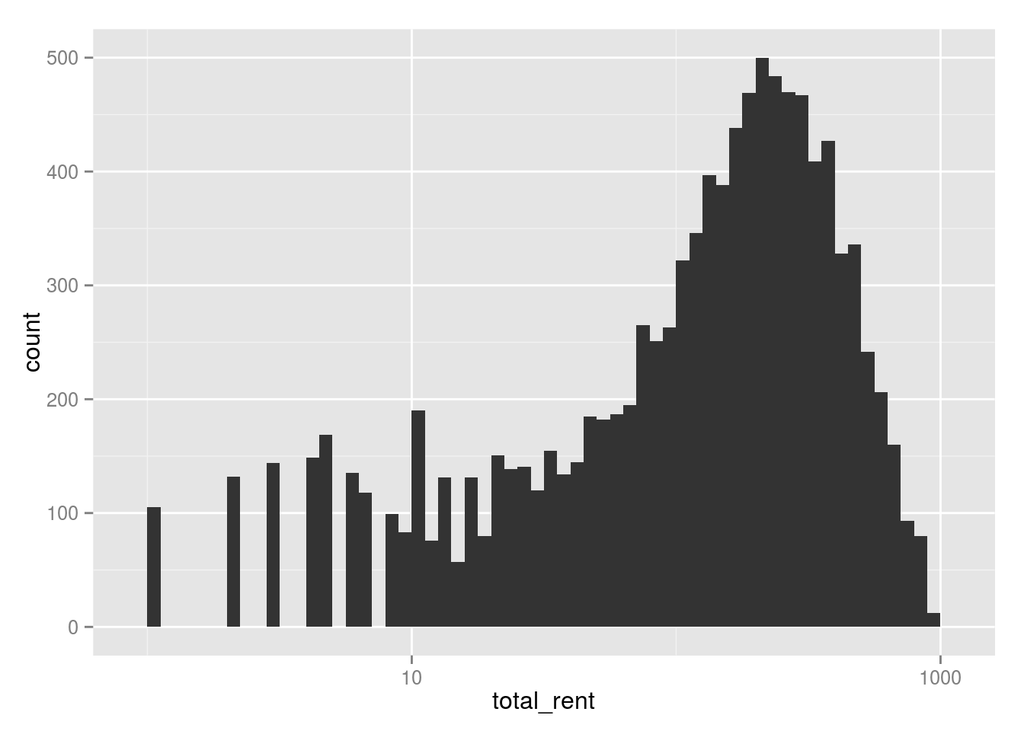

```r
ggplot(dts, aes(x=total_rent)) + geom_histogram(binwidth=0.05) + scale_x_log10()
```

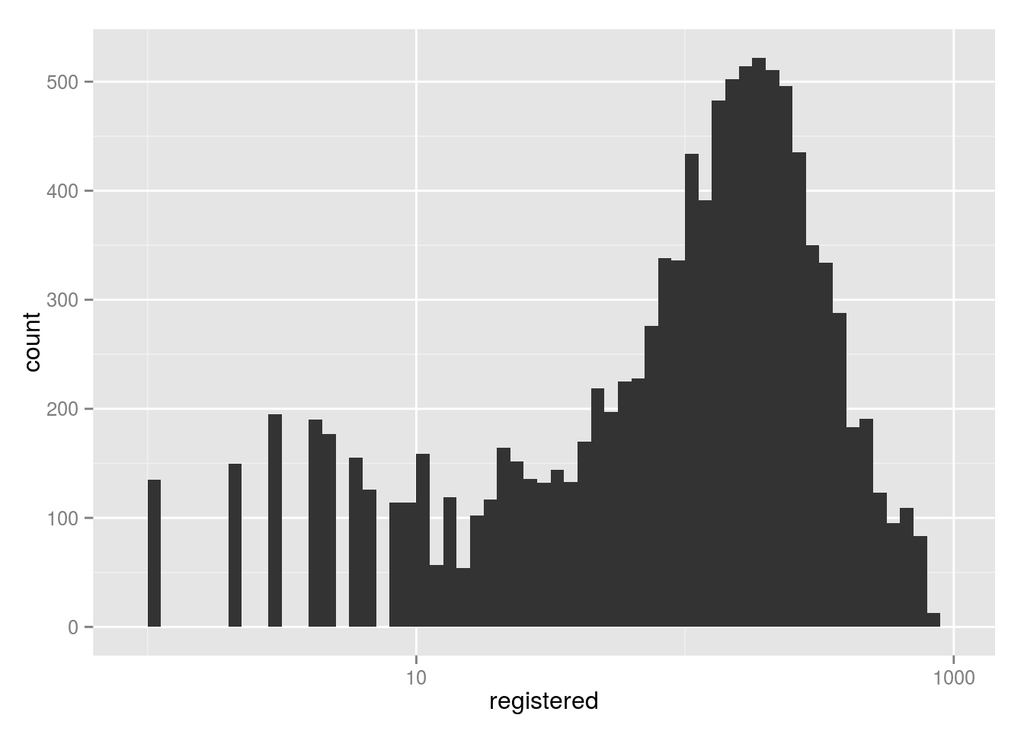

```r
ggplot(dts, aes(x=registered)) + geom_histogram(binwidth=0.05) + scale_x_log10()
```

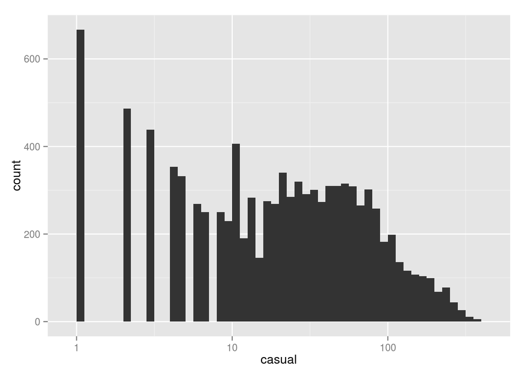

```r
ggplot(dts, aes(x=casual)) + geom_histogram(binwidth=0.05) + scale_x_log10()
```

```r
summary(dts$casual / dts$total_rent)
```

```
##    Min. 1st Qu.  Median    Mean 3rd Qu.    Max.
## 0.00000 0.06169 0.14470 0.17100 0.25340 1.00000
```

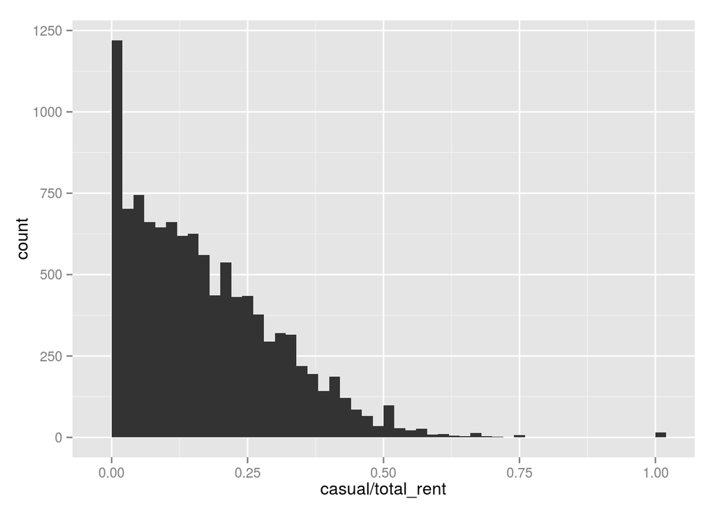

```r
ggplot(subset(dts, total_rent > 0), aes(x=casual/total_rent)) + geom_histogram(binwidth=0.02)
```

For the most of the time the casual riders are a small part of the “total_rent”; very often the casual riders are zero.

## Univariate analysis section

### What is/are the main feature(s) of interest in your dataset?

Of course the most important features of the dataset are ones about rentals. The goal here is to determine which of the other features are best for predicting rentals counts. After this first review I think that “workingday” and “hour” will be two of the most effective features for prediction. Probably, among climate features, “weather” and “temperature” will be the most useful.

### What other features in the dataset do you think will help support your investigation into your feature(s) of interest?

In my opinion “month” or “season” would be in some way useful to identify casual rentals made by tourists, probably also windspeed would influence the rentals count. On the contrary I think that “year”, or “day” will be useless or very ineffective, also “atemp” and “humidity” would be useless since they are repetitions of other features.

### Did you create any new variables from existing variables in the dataset?

Yes I did. The original dataset enclosed information about hour of the day, day of the month, month of the year and year in one single timestamp variable called “datetime”. I splitted this feature into four new features and removed the timestamp. Minutes and seconds have been discarded since they are always 0.

### Of the features you investigated, were there any unusual distributions? Did you perform any operations on the data to tidy, adjust, or change the form of the data? If so, why did you do this?

Yes I transformed in logarithmic scale the rentals data. The distribution is strongly skewed to 0 value; while the log-transformed distributions appear to be bimodal for “registered” and “total_rent” with two peaks at around 8 and 200. The casual rentals have an indefinite distribution, even if it reminds an exponential one.

## Bivariate plots section

I think that from now on I can ignore “total_rent” feature and analyze “registered” and “casual” features in separate ways. Total rentals count is always the sum of the other two rent types, so If good predictive models can be found for registered and casual a model for “total_rent” would be useless.

The response variable most influenced by temperature is “casual” rentals, while in the registered rentals the influence is still present but is less noticeable.

```r
cor(subset(dts, select=c( weather, temp, atemp, humidity, windspeed, registered)))
```

```
##                 weather        temp       atemp    humidity    windspeed
## weather     1.000000000 -0.05503542 -0.05537597  0.40624365  0.007261124
## temp       -0.055035418  1.00000000  0.98494811 -0.06494877 -0.017852010
## atemp      -0.055375973  0.98494811  1.00000000 -0.04353571 -0.057473002
## humidity    0.406243651 -0.06494877 -0.04353571  1.00000000 -0.318606992
## windspeed   0.007261124 -0.01785201 -0.05747300 -0.31860699  1.000000000
## registered -0.109340372  0.31857128  0.31463539 -0.26545787  0.091051662
##             registered
## weather    -0.10934037
## temp        0.31857128
## atemp       0.31463539
## humidity   -0.26545787
## windspeed   0.09105166
## registered  1.00000000
```

```r
cor(subset(dts,select=c(weather, temp, atemp, humidity, windspeed, casual)))
```

```
##                weather        temp       atemp    humidity    windspeed
## weather    1.000000000 -0.05503542 -0.05537597  0.40624365  0.007261124
## temp      -0.055035418  1.00000000  0.98494811 -0.06494877 -0.017852010
## atemp     -0.055375973  0.98494811  1.00000000 -0.04353571 -0.057473002
## humidity   0.406243651 -0.06494877 -0.04353571  1.00000000 -0.318606992
## windspeed  0.007261124 -0.01785201 -0.05747300 -0.31860699  1.000000000
## casual    -0.135917680  0.46709706  0.46206654 -0.34818690  0.092276189
##                casual
## weather   -0.13591768
## temp       0.46709706
## atemp      0.46206654
## humidity  -0.34818690
## windspeed  0.09227619
## casual     1.00000000
```

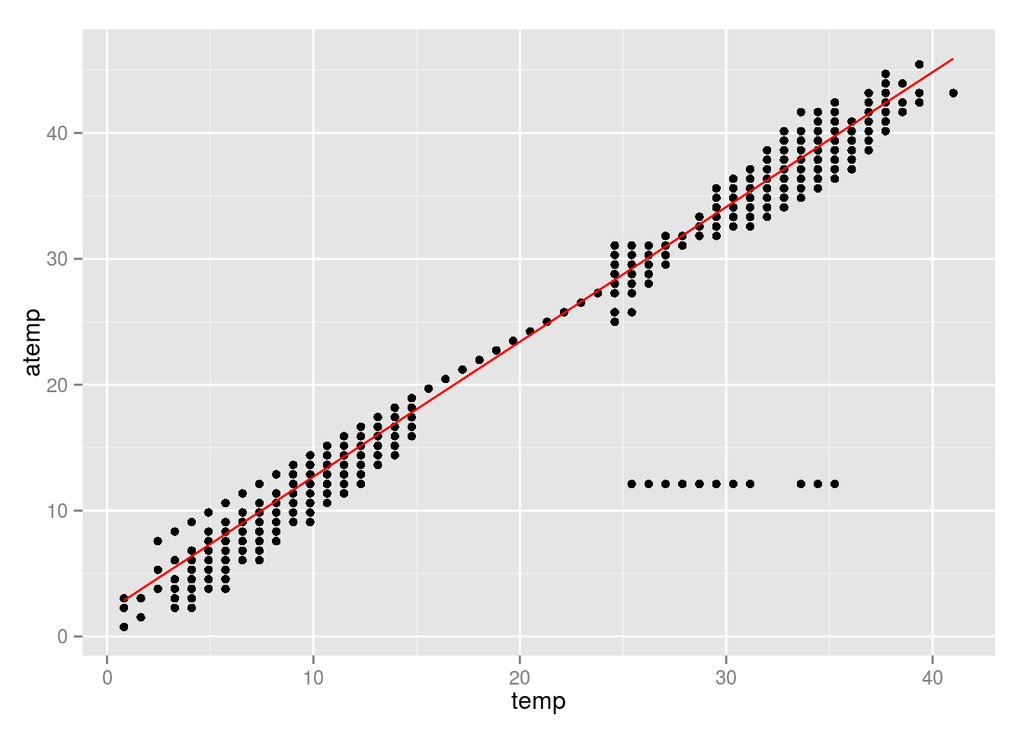

```r
ggplot(dts, aes(x=temp, y=atemp)) + geom_point() + geom_smooth(method='lm',color='red')
```

“temp” and “atemp” are very correlated, they almost have a determistic relation.

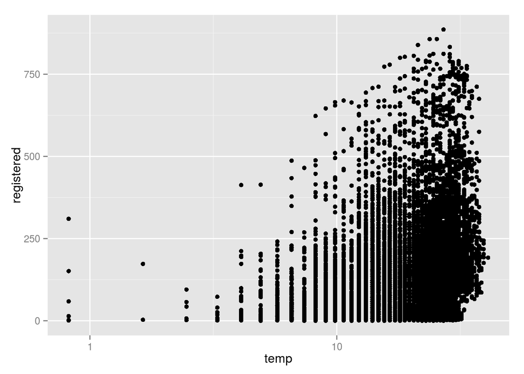

```r
ggplot(dts, aes(x=temp, y=registered)) + geom_point() + scale_x_log10()
```

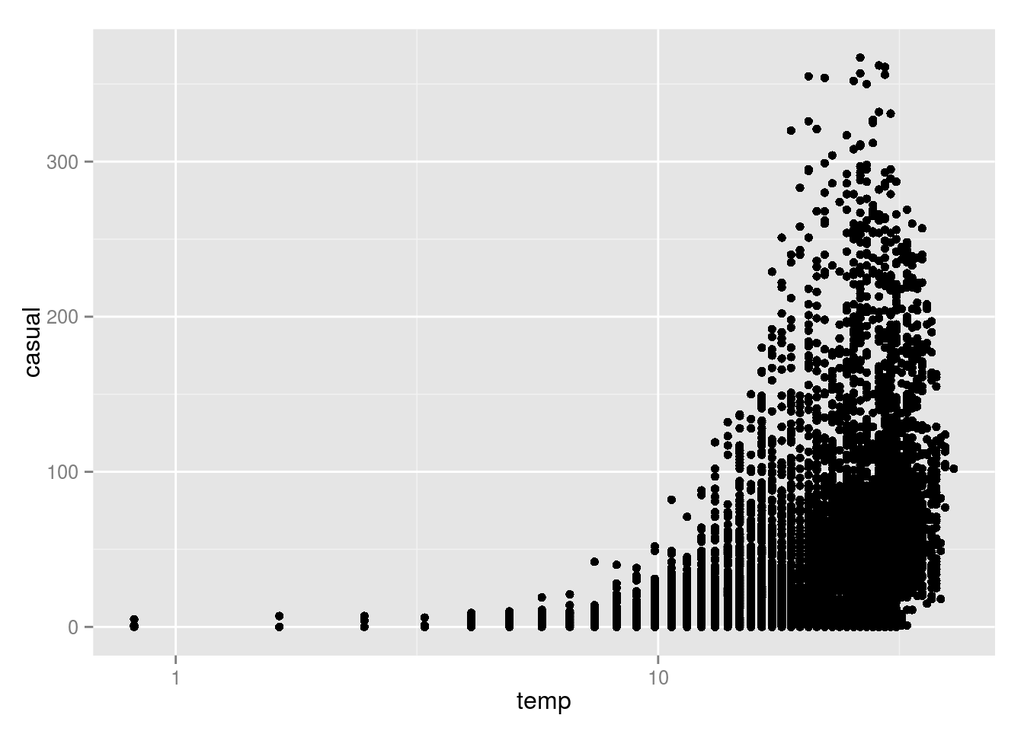

```r
ggplot(dts, aes(x=temp, y=casual)) + geom_point() + scale_x_log10()
```

Even if it looks that temperature affects registered rentals through a linear or even an exponential function, I think that it works more as an indicator function: below 10°degrees rentals have a uniform distribution very tight to 0, but as temperature rises above 10° the distribution spreads uniformly from 0 to 800. For casual rentals exponential relation seems to be stronger, but, the behavior is almost the same, probably the threshold value is little bit higher.

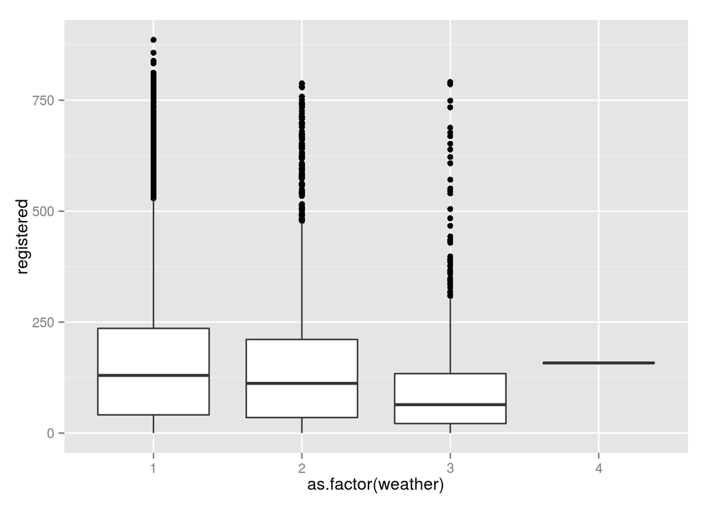

```r
ggplot(dts, aes(x=as.factor(weather), y=registered)) + geom_boxplot()
```

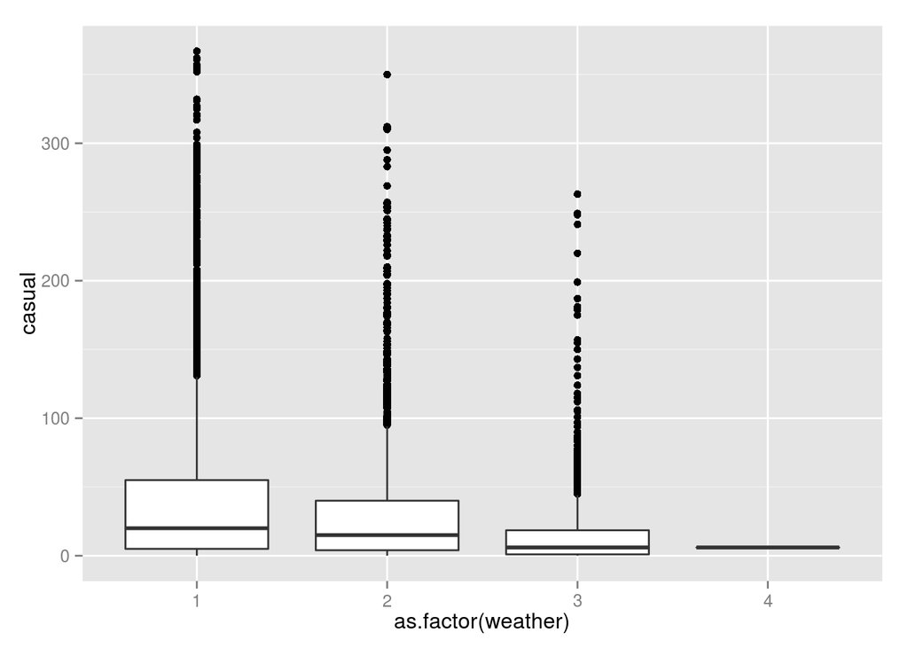

```r
ggplot(dts, aes(x=as.factor(weather), y=casual)) + geom_boxplot()
```

A look on humidity data:

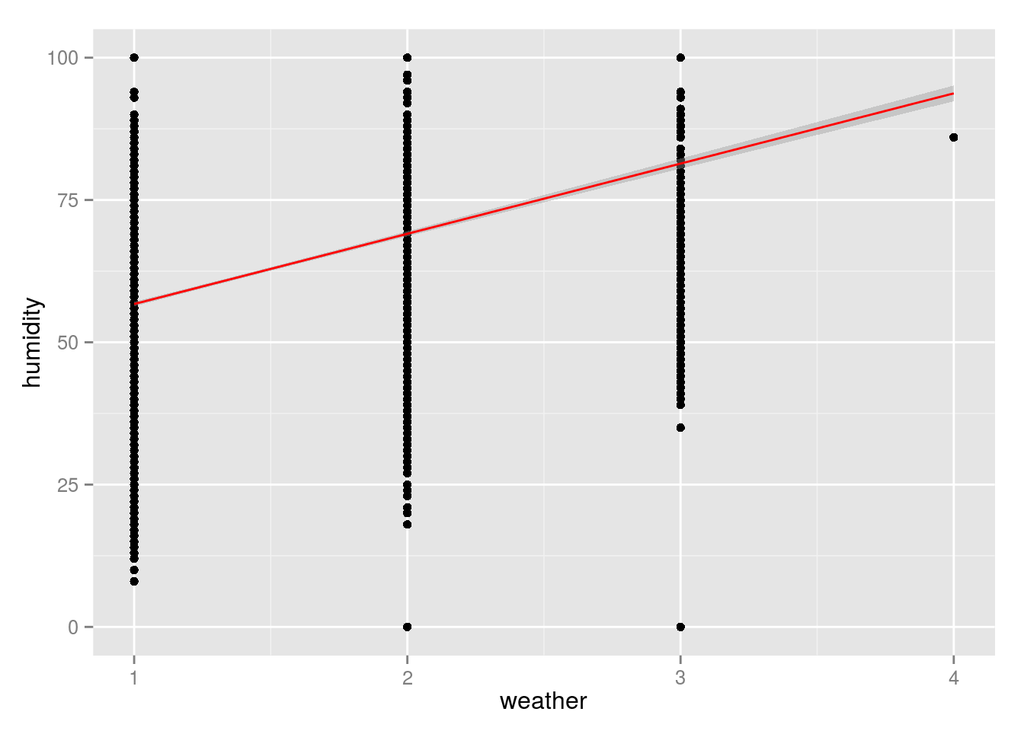

```r
ggplot(dts, aes(x=weather, y=humidity)) + geom_point() + geom_smooth(method='lm', color='red')
```

And as expected humidity is correlated to weather.

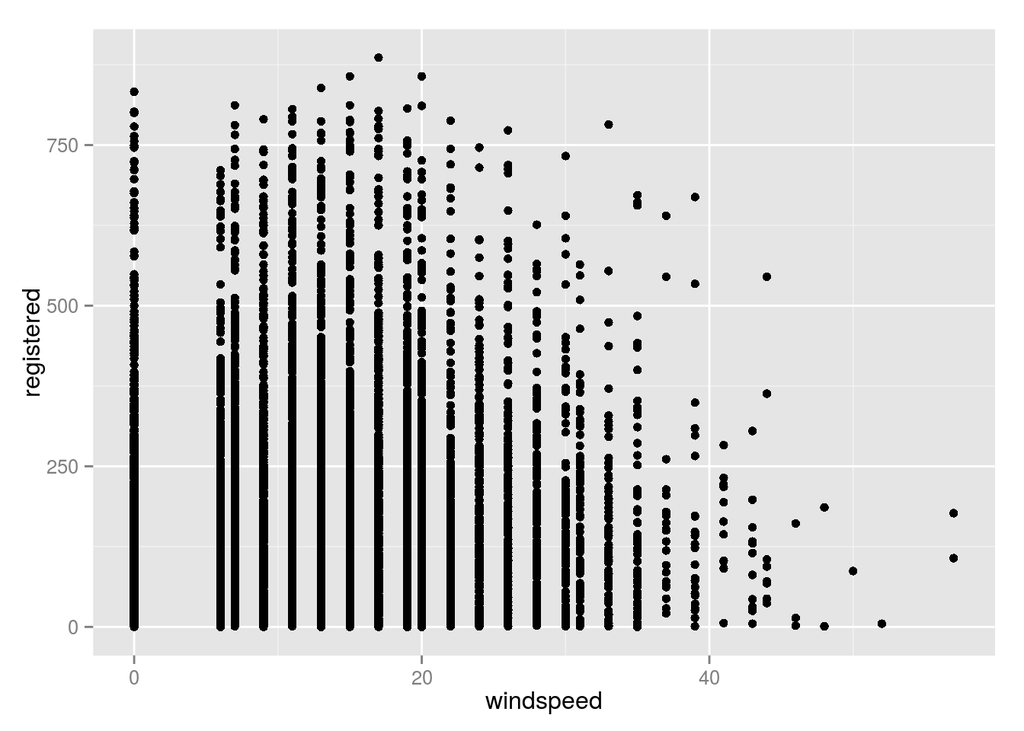

```r
ggplot(dts, aes(x=windspeed, y=registered)) + geom_point()
```

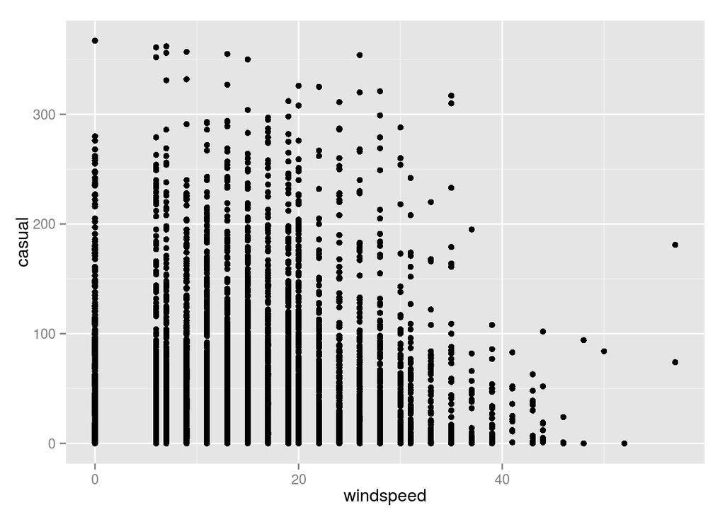

```r
ggplot(dts, aes(x=windspeed, y=casual)) + geom_point()
```

As for “weather”, the windspeed influences rents, almost only in the variance behavior. In case of very strong wind, rentals distribution tightens to zero. As “temp” the windspeed does not seem to have linear relation but more as a step function with a threshold at around 35 / 38 knots.

```r
cor(subset(dts,select=c(workingday, holiday, hour, day, month, season, registered)))
```

```
##              workingday       holiday          hour          day
## workingday  1.000000000 -0.2504913912  0.0027802345  0.009829427
## holiday    -0.250491391  1.0000000000 -0.0003541611 -0.015877453
## hour        0.002780234 -0.0003541611  1.0000000000  0.001132431
## day         0.009829427 -0.0158774525  0.0011324308  1.000000000
## month      -0.003394394  0.0017314575 -0.0068176434  0.001973618
## season     -0.008126058  0.0293676097 -0.0065456741  0.001728863
## registered  0.119459851 -0.0209556729  0.3805397262  0.019110637
##                   month       season  registered
## workingday -0.003394394 -0.008126058  0.11945985
## holiday     0.001731457  0.029367610 -0.02095567
## hour       -0.006817643 -0.006545674  0.38053973
## day         0.001973618  0.001728863  0.01911064
## month       1.000000000  0.971523800  0.16945110
## season      0.971523800  1.000000000  0.16401053
## registered  0.169451102  0.164010534  1.00000000
```

```r
cor(subset(dts,select=c(workingday, holiday, hour, day, month, season, casual)))
```

```
##              workingday       holiday          hour          day
## workingday  1.000000000 -0.2504913912  0.0027802345  0.009829427
## holiday    -0.250491391  1.0000000000 -0.0003541611 -0.015877453
## hour        0.002780234 -0.0003541611  1.0000000000  0.001132431
## day         0.009829427 -0.0158774525  0.0011324308  1.000000000
## month      -0.003394394  0.0017314575 -0.0068176434  0.001973618
## season     -0.008126058  0.0293676097 -0.0065456741  0.001728863
## casual     -0.319110963  0.0437989287  0.3020454019  0.014108702
##                   month       season      casual
## workingday -0.003394394 -0.008126058 -0.31911096
## holiday     0.001731457  0.029367610  0.04379893
## hour       -0.006817643 -0.006545674  0.30204540
## day         0.001973618  0.001728863  0.01410870
## month       1.000000000  0.971523800  0.09272204
## season      0.971523800  1.000000000  0.09675806
## casual      0.092722039  0.096758063  1.00000000
```

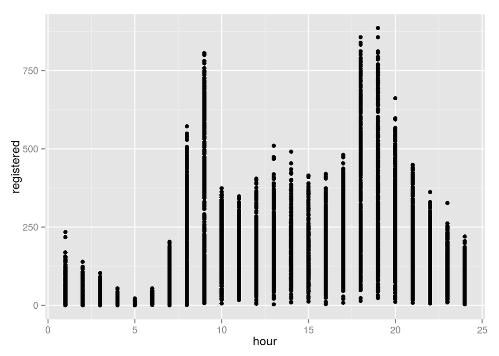

```r
ggplot(dts, aes(x=hour, y=registered)) + geom_point()
```

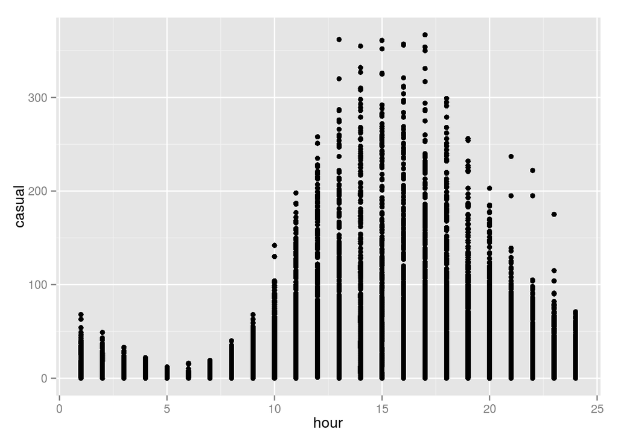

```r
ggplot(dts, aes(x=hour, y=casual)) + geom_point()
```

The behavior for registered and casual rentals based on hour is very different.

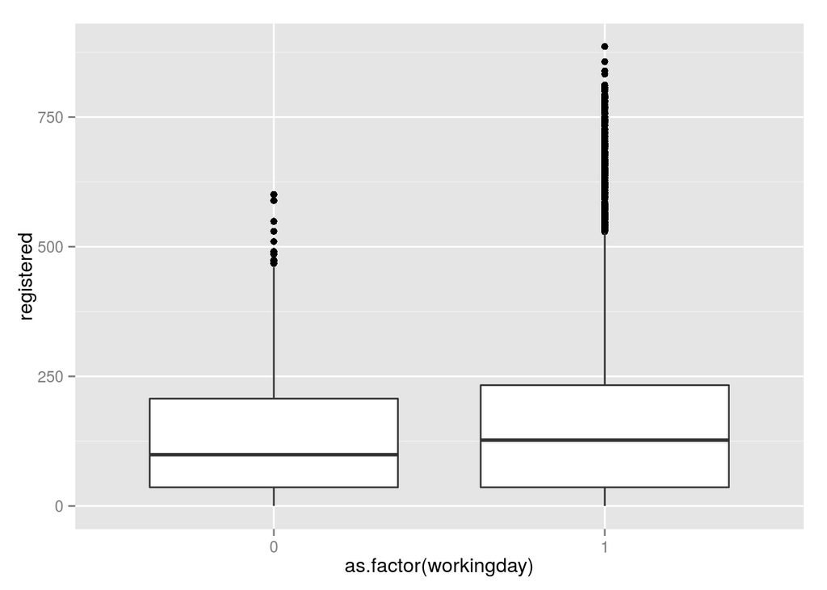

```r
ggplot(dts, aes(x=as.factor(workingday), y=registered)) + geom_boxplot()
```